# Rereading Books

Amber Thomas

Last updated: April 07, 2020

## Introduction

Several months ago, I had a conversation with my coworkers at The Pudding about books, movies, and TV shows that I re-watch/re-read. I love diving back into forms of entertainment that I’ve experienced before. Sometimes I do it because I crave something familiar and the story seems warm and cozy. Sometimes I feel like I do this to prevent “food-envy”, that is, the feeling I get when I try something new at a restaurant and wish that it was my tried and true favorite. Regardless of the reason, I found myself in the minority amongst my coworkers that actually likes to revisit media. It got me thinking about the books that other readers sink into time and time again.

### Load Packages

```r
# For general data cleaning and analysis
library(tidyverse)

# If your data includes dates that need to be wrangled
library(lubridate)

# For keeping your files in relative directories
library(here)

# For interactive/searchable tables in your report
library(DT)

# For Goodreads API
library(rgoodreads)

# For custom API access
library(httr)
library(xml2)
```

## Exploration

### My own data

To get a feel for how the Goodreads API works, I’ll start by using it to export my own reader data and see if I can get the data I need just through the API.

```r
# set my gr key into global environment like this: Sys.setenv("GOODREADS_KEY"='x'))
```

```r
myData <- rgoodreads::user(16950883)
glimpse(myData)
```

Hmm, looks like that’s not quite what I’m looking for. Maybe I’ll have to spin up my own functions for this.

```r
API_KEY <- Sys.getenv("GOODREADS_KEY")
URL <- "https://www.goodreads.com/review/list"
get_read_shelf <- function(userID) {
  shelf <- GET(URL, query = list(v = 2, key = API_KEY, id = userID, shelf = "read", per_page = 200))
  shelf_contents <- content(shelf, as = "parsed")
  return(shelf_contents)
}

myReadShelf <- get_read_shelf(1923002)

find_total <- function(shelf){
  kids <- xml_children(shelf)
  total <- xml_attr(kids[3], "total")

  tot <- shelf %>%
    xml_attrs()

  df <- tibble(total)

  return (df)
}

myTotal <- find_total(myReadShelf)

clean_shelf <- function(shelf){
  title <- shelf %>%
    xml_find_all("//title") %>%
    xml_text()

  author <- shelf %>%
    xml_find_all("//author") %>%
    xml_attrs()

  read_count <- shelf %>%
    xml_find_all("//read_count") %>%
    xml_text()

  read_at <- shelf %>%
    xml_find_all("//read_at") %>%
    xml_text()

  rating <- shelf %>%
    xml_find_all("//rating") %>%
    xml_text()



  df <- tibble(title, author, read_count, read_at, rating)
  return(author)
}

myCleanShelf <- clean_shelf(myReadShelf)
```

Ok, so I have all the pieces, now to write a function that can cycle through all of the pages necessary.

```r
parse_books <- function(contents, userID){
  title <- contents %>%
    xml_find_all("//title") %>%
    xml_text()

  author <- contents %>%
    xml_find_all("//name") %>%
    xml_text()

  read_count <- contents %>%
    xml_find_all("//read_count") %>%
    xml_text()

  read_at <- contents %>%
    xml_find_all("//read_at") %>%
    xml_text()

  rating <- contents %>%
    xml_find_all("//rating") %>%
    xml_text()

  df <- tibble(userID, title, author, read_count, read_at, rating)

  # define the location and filename for the new file
  fileName = here::here("assets", "data", "raw_data", "rereads.csv")

  # export the data to a csv
    write.table(df, file = fileName, row.names = FALSE, append = TRUE, sep = ",", col.names = !file.exists(fileName))
}
```

```r
get_first_page <- function(userID){
  URL <- "https://www.goodreads.com/review/list"
  # collects the data from the first page, including the total number of books on the user's "read" shelf
  shelf <- GET(URL, query = list(v = 2, key = API_KEY, id = userID, shelf = "read", per_page = 200, page = 1))
  status <- status_code(shelf)
  shelf_contents <- content(shelf, as = "parsed")

  # TODO: parse the shelf contents and export to file
  parse_books(shelf_contents, userID)

  # finds total number of books on "read" shelf and returns that number
  kids <- xml_children(shelf_contents)
  total <- xml_attr(kids[3], "total") %>% as.numeric()
  return(total)
}
```

```r
get_subsequent_pages <- function(userID, page_number){
  URL <- "https://www.goodreads.com/review/list"
  shelf <- GET(URL, query = list(v = 2, key = API_KEY, id = userID, shelf = "read", per_page = 200, page = page_number))
  shelf_contents <- content(shelf, as = "parsed")

  parse_books(shelf_contents, userID)
}
```

```r
add_ID <- function(userID){
  alreadyChecked <- as_tibble(userID)

  # define the location and filename for the new file
  fileName = here::here("assets", "data", "raw_data", "users.csv")

  # export the data to a csv
    write.table(alreadyChecked, file = fileName, row.names = FALSE, append = TRUE, sep = ",", col.names = !file.exists(fileName))
}
```

```r
find_rereads <- function(userID){
  API_KEY <- Sys.getenv("GOODREADS_KEY")
  URL <- "https://www.goodreads.com/review/list"

  total <- get_first_page(userID)

  if (class(total) == "numeric" & total > 200){
    totalPages <- ceiling(total / 200)

    # 200 results allowed per page
    breakpoints <- seq(2, totalPages, by = 1)

    walk2(userID, breakpoints, get_subsequent_pages)
  }
}

possibly_find_rereads <- purrr::possibly(find_rereads, otherwise = NA)
```

### Mara’s Data

Let’s start by looking at Mara Averick’s read books (since she has quite a few)

```r
find_rereads(1923002)
```

```r
mara <- read.csv(here::here("assets", "data", "raw_data", "rereads.csv"))
glimpse(mara)
```

```
## Observations: 563,921
## Variables: 6
## $ userID     <fct> 46444326, 46444326, 46444326, 46444326, 46444326, 46444326…
## $ title      <fct> "A Year of Extraordinary Moments (Magnolia Grove #2)", "If…
## $ author     <fct> Bette Lee Crosby, Gregg Olsen, Jess Lourey, William Damero…
## $ read_count <fct> 1, 1, 1, 1, 1, 1, 1, 1, 1, 1, 1, 1, 1, 1, 1, 1, 1, 1, 1, 1…
## $ read_at    <fct> , Fri Dec 27 13:43:53 -0800 2019, Thu Dec 19 18:30:49 -080…
## $ rating     <fct> 5, 5, 0, 0, 0, 0, 5, 0, 5, 4, 4, 5, 4, 5, 5, 3, 4, 0, 0, 0…
```

Amazing, that seems to be working great!

### Most Recent Reviewers

Now to get lots of user ids to parse through. The simplest way to do that may be to find the users that recently updated something and find all the books on their “read” shelf. Looks like this caps at 20 users, so I’ll start there.

```r
find_recent_reviews <- function(){
  API_KEY <- Sys.getenv("GOODREADS_KEY")
  URL <- "https://www.goodreads.com/review/list"
  recent <- rgoodreads::recent_reviews() %>%
    separate(col = user, c("userName", "userID"), ":")

  # load in the already checked ID's
  alreadyChecked <- read.csv(here::here("assets", "data", "raw_data", "users.csv"))

  # find only new IDs
  newIDs <- recent %>%
    filter(!userID %in% alreadyChecked$value)

  # add new IDs to the list so they don't get double checked
  walk(newIDs$userID, add_ID)

  # find rereads for all users of recently reviewed things
  walk(newIDs$userID, possibly_find_rereads)
}

find_recent_reviews()
```

```r
keep_finding_reviews <- function(i, .pb = NULL){
  # progress bar stuff
  if ((!is.null(.pb)) && inherits(.pb, "Progress") && (.pb$i < .pb$n)) .pb$tick()$print()

  # sleep for 10 minutes
  Sys.sleep(200)

  # look for recent reviews
  find_recent_reviews()
}

loops <- seq(1, 6)
pb <- progress_estimated(length(loops))
walk(loops, keep_finding_reviews, .pb = pb)
```

```r
reads <- read.csv(here::here("assets", "data", "raw_data", "rereads.csv"))
```

Ok, so let’s see how many books were reread.

```r
rereads <- reads %>%
  mutate(read_count = as.numeric(as.character(read_count))) %>%
  filter(read_count > 1)

nrow(rereads)
```

```
## [1] 18902
```

Wow, ok, so out of the 563921 books that were read by these 1081 users, 18902 (3%) were reread at least once. And, 753 (70%) of the readers randomly surveyed re-read books.

Let’s see what other questions we can start to answer.

### Most re-read book

Is everyone re-reading the same book?

```r
uniqueBook <- rereads %>%
  distinct(userID, title) %>%
  count(title)

unique100 <- uniqueBook %>%
  arrange(desc(n)) %>%
  top_n(50)
unique100
```

| title | n |
| --- | --- |
| Harry Potter and the Sorcerer's Stone (Harry Potter, #1) | 19 |
| Harry Potter and the Chamber of Secrets (Harry Potter, #2) | 16 |
| Harry Potter and the Deathly Hallows (Harry Potter, #7) | 12 |
| Harry Potter and the Goblet of Fire (Harry Potter, #4) | 11 |
| Harry Potter and the Order of the Phoenix (Harry Potter, #5) | 11 |
| Educated | 9 |
| Harry Potter and the Half-Blood Prince (Harry Potter, #6) | 9 |
| Harry Potter and the Prisoner of Azkaban (Harry Potter, #3) | 9 |
| Housekeeping | 9 |
| The Hunger Games (The Hunger Games, #1) | 9 |

[output cut: 42 more lines]

Well, ok, looks like Harry Potter and other YA fantasy series (Hunger Games, Percy Jackson) are frequently re-read, along with some romance novels.

### How many times do users re-read?

Does a single user re-read the same story over and over? Or have they read several stories multiple times?

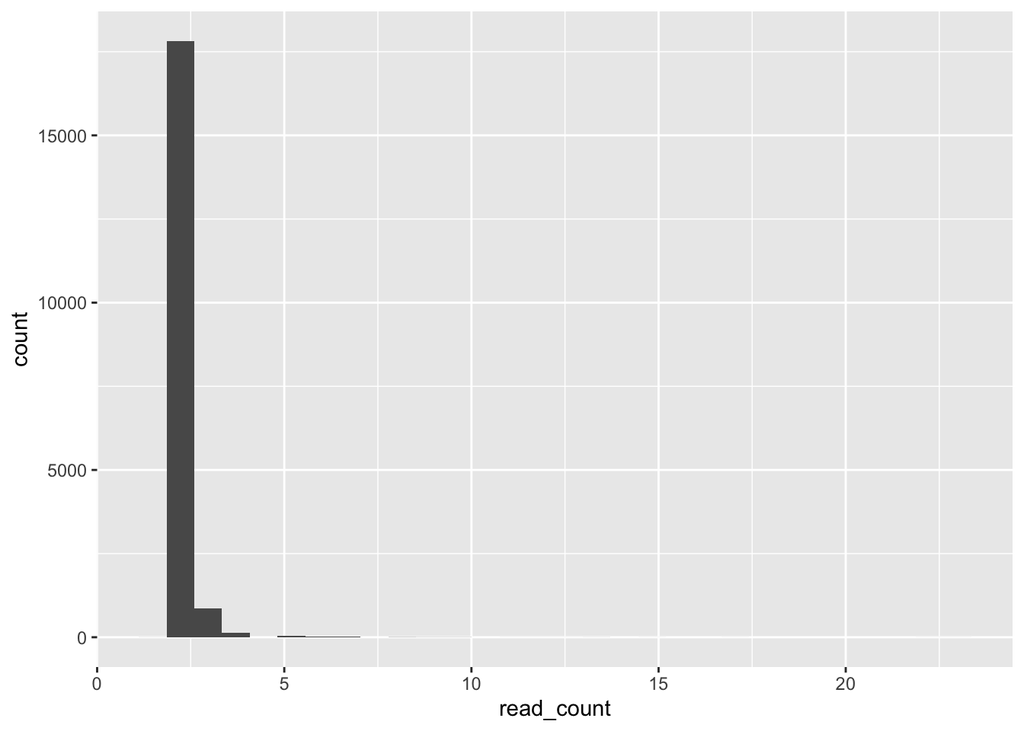

```r
ggplot(rereads, aes(x = read_count)) + geom_histogram()
```

Ok, so most of the books were reread just twice. Let’s look at the ones that users reread more than that.

```r
readManyTimes <- rereads %>%
  filter(read_count > 2) %>%
  arrange(desc(read_count))

head(readManyTimes)
```

|  | userID | title | author | read_count | read_at | rating |
| --- | --- | --- | --- | --- | --- | --- |
| 1 | 85347537 | The Hobbit, or There and Back Again | J.R.R. Tolkien | 23 | Sat Nov 30 08:07:59 -0800 2019 | 5 |
| 2 | 845438 | The Wishing Trees | John Shors | 22 | Thu Feb 25 00:00:00 -0800 2010 | 5 |
| 3 | 3279943 | Protect My Heart | Judy Corry | 17 | Mon Sep 04 14:20:00 -0700 2017 | 5 |
| 4 | 2837028 | Whitney, My Love (Westmoreland, #2) | Judith McNaught | 15 | Mon Jun 01 00:00:00 -0700 1998 | 5 |
| 5 | 7510654 | L'être et le néant : essai d'ontologie phénoménologique | Jean-Paul Sartre | 13 | Fri Feb 19 13:56:21 -0800 2016 | 5 |
| 6 | 7510654 | The Lord of the Rings (The Lord of the Rings, #1-3) | J.R.R. Tolkien | 13 | Fri Feb 13 17:41:12 -0800 2015 | 5 |

Wow, that one user *really* likes **The Hobbit**.

What’s the average number of times different titles have been re-read?

```r
avgReads <- rereads %>%
  group_by(title, author) %>%
  summarise(avg = mean(read_count), count = n()) %>%
  arrange(desc(avg))

head(avgReads, 10)
```

| title | author | avg | count |
| --- | --- | --- | --- |
| The Wishing Trees | John Shors | 22.0 | 1 |
| Protect My Heart | Judy Corry | 17.0 | 1 |
| Whitney, My Love (Westmoreland, #2) | Judith McNaught | 15.0 | 1 |
| L'être et le néant : essai d'ontologie phénoménologique | Jean-Paul Sartre | 13.0 | 1 |
| The Lord of the Rings (The Lord of the Rings, #1-3) | J.R.R. Tolkien | 13.0 | 1 |
| #1),Gregory Maguire,1,",5\n5187501,Three in Death (In Death | #7.5 | 12.5 | 1 |
| A Christmas Carol / The Chimes / The Cricket on the Hearth | Charles Dickens | 12.0 | 1 |
| Walden | Henry David Thoreau | 11.0 | 1 |
| Paradise Lost | John Milton | 10.0 | 1 |
| Possession | A.S. Byatt | 10.0 | 1 |

Hmm, many of these favorites are re-read only by a single user. Maybe I should look at how many people have read each title at all.

```r
overallRead <- reads %>%
  mutate(read_count = as.numeric(as.character(read_count))) %>%
  filter(!is.na(read_count)) %>%
  filter(title %in% uniqueBook$title) %>%
  group_by(title, author) %>%
  summarise(avg = mean(read_count), count = n()) %>%
  arrange(desc(avg))

head(overallRead)
```

| title | author | avg | count |
| --- | --- | --- | --- |
| L'être et le néant : essai d'ontologie phénoménologique | Jean-Paul Sartre | 13.0 | 1 |
| #1),Gregory Maguire,1,",5\n5187501,Three in Death (In Death | #7.5 | 12.5 | 1 |
| Sleepyhead | Karma Wilson | 10.0 | 1 |
| Green Eyes | Amanda Heath | 9.0 | 1 |
| Protect My Heart | Judy Corry | 9.0 | 2 |
| 4.7 | 8.1 | 8.2 | 1 |

### Date of re-reading

Lots of people are currently self-quarantined, has there been any increase in rereading old, comfortable favorites?

```r
lastReRead <- rereads %>%
  separate(read_at, into =c("weekday", "month", "day", "time", "zone", "year"), sep = " ", fill = "right") %>%
  mutate(date = paste0(month, "-", day, "-", year)) %>%
  mutate(date = lubridate::mdy(date)) %>%
  group_by(year, month) %>%
  summarise(count = n()) %>%
  ungroup() %>%
  mutate(year = as.numeric(as.character(year))) %>%
  filter(!is.na(year)) %>%
  filter(year >= 2017)

lrrGraph <- lastReRead %>%
  mutate(year = as.factor(year),
         month = factor(month, levels = month.abb))
```

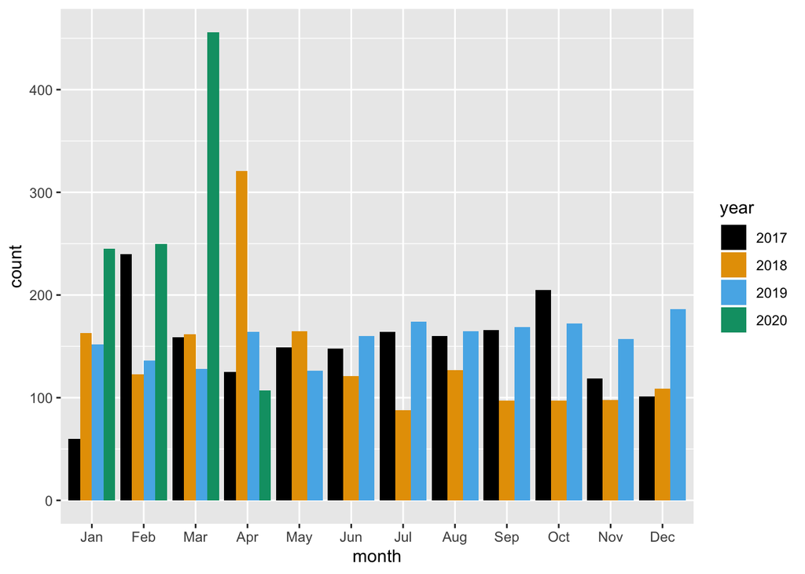

```r
cbbPalette <- c("#000000", "#E69F00", "#56B4E9", "#009E73", "#F0E442", "#0072B2", "#D55E00", "#CC79A7")

ggplot(lrrGraph, aes(month, fill = year)) +
  geom_bar(aes(weight = count), position = "dodge") +
  scale_fill_manual(values = cbbPalette)
```

Let’s see if the rate of reading overall has spiked during this time.

```r
lastRead <- reads %>%
  separate(read_at, into =c("weekday", "month", "day", "time", "zone", "year"), sep = " ", fill = "right") %>%
  mutate(date = paste0(month, "-", day, "-", year)) %>%
  mutate(date = lubridate::mdy(date)) %>%
  group_by(year, month) %>%
  summarise(count = n()) %>%
  ungroup() %>%
  mutate(year = as.numeric(as.character(year))) %>%
  filter(!is.na(year)) %>%
  filter(year >= 2017)

lrGraph <- lastRead %>%
  mutate(year = as.factor(year),
         month = factor(month, levels = month.abb))
```

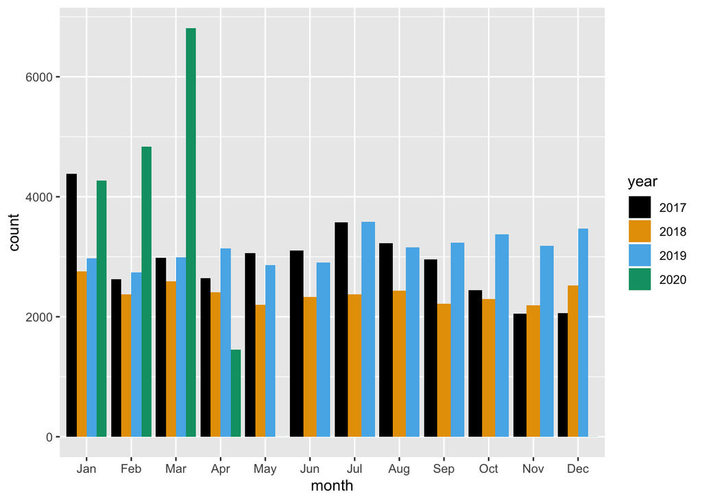

```r
cbbPalette <- c("#000000", "#E69F00", "#56B4E9", "#009E73", "#F0E442", "#0072B2", "#D55E00", "#CC79A7")

ggplot(lrGraph, aes(month, fill = year)) +
  geom_bar(aes(weight = count), position = "dodge") +
  scale_fill_manual(values = cbbPalette)
```

Ok, so we see a very similar pattern of increased reading happening at the start of 2020. What about the ratio of read to re-read books per month over this time span?

```r
ratio <- lastRead %>%
  rename(reads = count) %>%
  left_join(lastReRead) %>%
  rename(rereads = count) %>%
  mutate(ratio = rereads/reads)
```

```r
ratioGraph <- ratio %>%
  mutate(year = as.factor(year),
         month = factor(month, levels = month.abb)) %>%
  arrange(year, month)
```

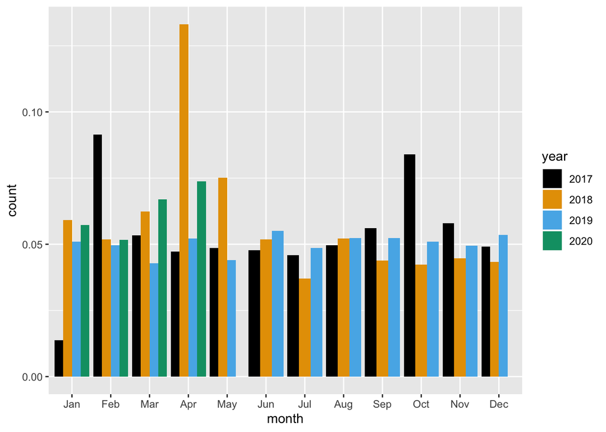

```r
cbbPalette <- c("#000000", "#E69F00", "#56B4E9", "#009E73", "#F0E442", "#0072B2", "#D55E00", "#CC79A7")

ggplot(ratioGraph, aes(month, fill = year)) +
  geom_bar(aes(weight = ratio), position = "dodge") +
  scale_fill_manual(values = cbbPalette)
```

Alright, so the ratio of re-reads to read books has been higher so far in March & April than it was at the same time in 2019, but not much higher than in 2018.

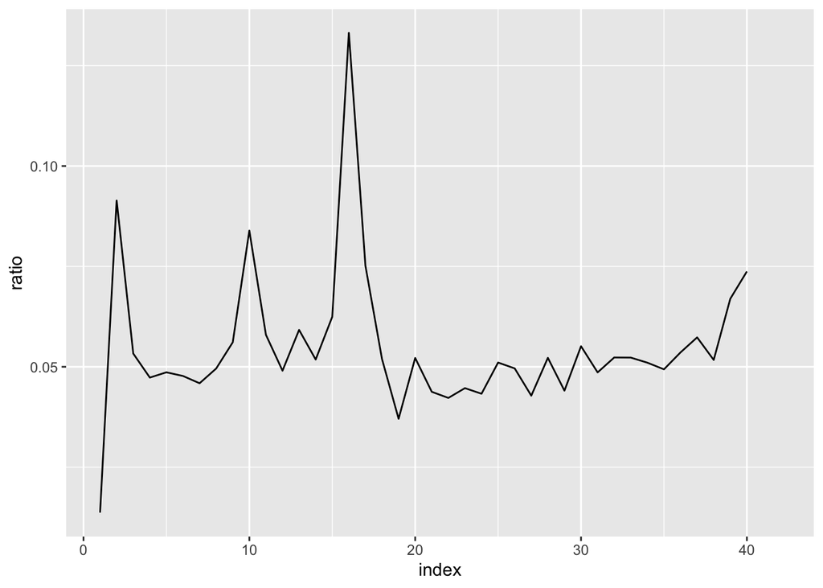

```r
ratioLine <- ratioGraph %>%
  mutate(index = row_number())

ggplot(ratioLine, aes(x = index, y = ratio)) + geom_line()
```